# Credit card

```python
import numpy as np
import pandas as pd
import seaborn as sns
import matplotlib.pyplot as plt
from sklearn.model_selection import train_test_split
from sklearn import metrics
from sklearn import preprocessing
from sklearn.linear_model import LogisticRegression
from sklearn.tree import DecisionTreeClassifier
import lightgbm as ltb
from sklearn.ensemble import RandomForestRegressor
import statsmodels.api as sm
```

### Attribute Information:

This research employed a binary variable, default payment (Yes = 1, No = 0), as the response variable. This study reviewed the literature and used the following 23 variables as explanatory variables:  
X1: Amount of the given credit (NT dollar): it includes both the individual consumer credit and his/her family (supplementary) credit.  
X2: Gender (1 = male; 2 = female).  
X3: Education (1 = graduate school; 2 = university; 3 = high school; 4 = others).  
X4: Marital status (1 = married; 2 = single; 3 = others).  
X5: Age (year).  
X6 - X11: History of past payment. We tracked the past monthly payment records (from April to September, 2005) as follows:  
X6 = the repayment status in September, 2005;  
X7 = the repayment status in August, 2005; . . .;  
X11 = the repayment status in April, 2005.

- The measurement scale for the repayment status is: -1 = pay duly; 1 = payment delay for one month; 2 = payment delay for two months; . . .; 8 = payment delay for eight months; 9 = payment delay for nine months and above.

X12-X17: Amount of bill statement (NT dollar).  
X12 = amount of bill statement in September, 2005;  
X13 = amount of bill statement in August, 2005; . . .;  
X17 = amount of bill statement in April, 2005.  
X18-X23: Amount of previous payment (NT dollar).  
X18 = amount paid in September, 2005;  
X19 = amount paid in August, 2005; . . .;  
X23 = amount paid in April, 2005.

```python
df=pd.read_csv("credit_card.csv")
```

```python
df.columns
```

```
Index(['ID', 'X1', 'X2', 'X3', 'X4', 'X5', 'X6', 'X7', 'X8', 'X9', 'X10',
       'X11', 'X12', 'X13', 'X14', 'X15', 'X16', 'X17', 'X18', 'X19', 'X20',
       'X21', 'X22', 'X23', 'Y'],
      dtype='object')
```

```python
df.head()
```

|  | ID | X1 | X2 | X3 | X4 | X5 | X6 | X7 | X8 | X9 | ... | X15 | X16 | X17 | X18 | X19 | X20 | X21 | X22 | X23 | Y |
| --- | --- | --- | --- | --- | --- | --- | --- | --- | --- | --- | --- | --- | --- | --- | --- | --- | --- | --- | --- | --- | --- |
| 0 | 1 | 20000 | 2 | 2 | 1 | 24 | 2 | 2 | -1 | -1 | ... | 0 | 0 | 0 | 0 | 689 | 0 | 0 | 0 | 0 | 1 |
| 1 | 2 | 120000 | 2 | 2 | 2 | 26 | -1 | 2 | 0 | 0 | ... | 3272 | 3455 | 3261 | 0 | 1000 | 1000 | 1000 | 0 | 2000 | 1 |
| 2 | 3 | 90000 | 2 | 2 | 2 | 34 | 0 | 0 | 0 | 0 | ... | 14331 | 14948 | 15549 | 1518 | 1500 | 1000 | 1000 | 1000 | 5000 | 0 |
| 3 | 4 | 50000 | 2 | 2 | 1 | 37 | 0 | 0 | 0 | 0 | ... | 28314 | 28959 | 29547 | 2000 | 2019 | 1200 | 1100 | 1069 | 1000 | 0 |
| 4 | 5 | 50000 | 1 | 2 | 1 | 57 | -1 | 0 | -1 | 0 | ... | 20940 | 19146 | 19131 | 2000 | 36681 | 10000 | 9000 | 689 | 679 | 0 |

5 rows × 25 columns

```python
cols=['ID', 'X1', 'X2', 'X3', 'X4', 'X5', 'X6', 'X7', 'X8', 'X9', 'X10',
       'X11', 'X12', 'X13', 'X14', 'X15', 'X16', 'X17', 'X18', 'X19', 'X20',
       'X21', 'X22', 'X23']
```

```python
min_max_scaler = preprocessing.MinMaxScaler()
x = df[cols].values.astype(float)
```

```python
x_scaled = min_max_scaler.fit_transform(x)
df_normalized = pd.DataFrame(x_scaled)
```

```python
df_normalized = pd.DataFrame(min_max_scaler.fit_transform(df[cols].values.astype(float)))
df_normalized.columns=['ID', 'X1', 'X2', 'X3', 'X4', 'X5', 'X6', 'X7', 'X8', 'X9', 'X10',
       'X11', 'X12', 'X13', 'X14', 'X15', 'X16', 'X17', 'X18', 'X19', 'X20',
       'X21', 'X22', 'X23']
```

```python
df_normalized['ID']=df_others['ID']
df_normalized['X2']=df_others['X2']
df_normalized['X3']=df_others['X3']
df_normalized['X4']=df_others['X4']
df_normalized['Y']=df_others['Y']
```

```python
df.isnull().any().any()
```

```
False
```

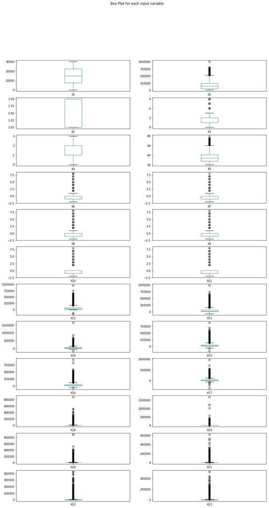

```python
df.drop('Y', axis=1).plot(kind='box', subplots=True, layout=(12,2), sharex=False, sharey=False, figsize=(16,29),
                                        title='Box Plot for each input variable')
plt.show()
```

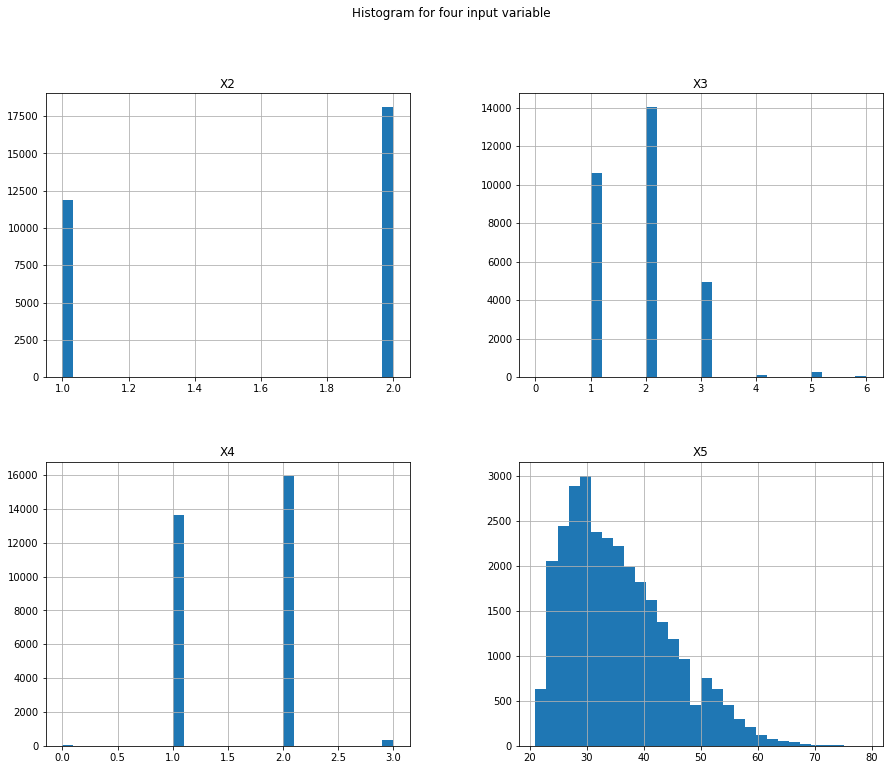

```python
cols=[ 'X2', 'X3', 'X4', 'X5']
import pylab as pl
df[cols].hist(bins=30, figsize=(15,12))
pl.suptitle("Histogram for four input variable")
plt.show()
```

```python
df['Y'].value_counts(normalize= True) #It gives the ratios of 1 and 0 values on the dependent variable
```

```
0    0.7788
1    0.2212
Name: Y, dtype: float64
```

```python
X = df_normalized
y = df['Y']
```

```python
from sklearn.model_selection import train_test_split
X_train, X_test, y_train, y_test = train_test_split(X, y, test_size=0.3, random_state=0)
```

```python
X_train.shape
```

```
(21000, 24)
```

```python
lr = LogisticRegression()
lr.fit(X_train, y_train)
```

```
LogisticRegression(C=1.0, class_weight=None, dual=False, fit_intercept=True,
          intercept_scaling=1, max_iter=100, multi_class='warn',
          n_jobs=None, penalty='l2', random_state=None, solver='warn',
          tol=0.0001, verbose=0, warm_start=False)
```

```python
lr_pred=lr.predict(X_test)
print('Accuracy score of logistic regression= {}'.format(metrics.accuracy_score(y_test, lr_pred)))
print('Confusion Matrix is;')
print(metrics.confusion_matrix(y_test, lr_pred))
```

```
Accuracy score of logistic regression= 0.8147777777777778
Confusion Matrix is;
[[6908  152]
 [1515  425]]
```

```python
clf = DecisionTreeClassifier()
clf = clf.fit(X_train,y_train)
```

```python
y_pred_test = clf.predict(X_test)
print('Accuracy score of logistic regression= {}'.format(metrics.accuracy_score(y_test, y_pred_test)))
print('Confusion Matrix is;')
print(metrics.confusion_matrix(y_test, y_pred_test))
```

```
Accuracy score of logistic regression= 0.7266666666666667
Confusion Matrix is;
[[5739 1321]
 [1139  801]]
```

#### Because desiciontree classifier uses the Gini criterion, none max_depth and 1 min_samples_leaf as a default value I wanted to find the best parameter for our data by changing parameters.

```python
optimum_accuracy=0
for i in range(1,20):
    for k in range(1,10):
        clf=DecisionTreeClassifier(max_depth=i,min_samples_leaf=k)
        clf=clf.fit(X_train,y_train)
        clf_pred=clf.predict(X_test)
        if(metrics.accuracy_score(y_test, clf_pred))>optimum_accuracy:
            optimum_accuracy=metrics.accuracy_score(y_test, clf_pred)
            optimum_i,optimum_k=[i,k]

print('optimum_accuracy={}'.format(optimum_accuracy))
print('optimum_max_depth={}'.format(optimum_i))
print('optimum_min_samples_leaf={}'.format(optimum_k))
```

```
optimum_accuracy=0.826
optimum_max_depth=1
optimum_min_samples_leaf=1
```

```python
for i in range(1,20):
    for k in range(1,10):
        clf=DecisionTreeClassifier(criterion="entropy",max_depth=i,min_samples_leaf=k)
        clf=clf.fit(X_train,y_train)
        clf_pred=clf.predict(X_test)
        if(metrics.accuracy_score(y_test, clf_pred))>optimum_accuracy:
            optimum_accuracy=metrics.accuracy_score(y_test, clf_pred)
            optimum_i,optimum_k=[i,k]
print('optimum_accuracy={}'.format(optimum_accuracy))
print('optimum_max_depth={}'.format(optimum_i))
print('optimum_min_samples_leaf={}'.format(optimum_k))
```

```
optimum_accuracy=0.826
optimum_max_depth=1
optimum_min_samples_leaf=1
```

```python
clf=DecisionTreeClassifier(max_depth=optimum_i,min_samples_leaf=optimum_k)
clf=clf.fit(X_train,y_train)
clf_pred=clf.predict(X_test)
print('Accuracy score of DecisionTree= {}'.format(metrics.accuracy_score(y_test, clf_pred)))
print('Confusion Matrix is;')
print(metrics.confusion_matrix(y_test, clf_pred))
```

```
Accuracy score of DecisionTree= 0.826
Confusion Matrix is;
[[6791  269]
 [1297  643]]
```

```python
lgbm = ltb.LGBMClassifier()
lgbm.fit(X_train, y_train)
lgbm_pred=lgbm.predict(X_test)
print('Accuracy score of LGBMClassifier = {}'.format(metrics.accuracy_score(y_test, lgbm_pred)))
print('Confusion Matrix is;')
print(metrics.confusion_matrix(y_test, lgbm_pred))
```

```
Accuracy score of LGBMClassifier = 0.8237777777777778
Confusion Matrix is;
[[6700  360]
 [1226  714]]
```

```python
rfr = RandomForestRegressor(n_estimators = 100, random_state = 0)
rfr.fit(X_train, y_train)
```

```
RandomForestRegressor(bootstrap=True, criterion='mse', max_depth=None,
           max_features='auto', max_leaf_nodes=None,
           min_impurity_decrease=0.0, min_impurity_split=None,
           min_samples_leaf=1, min_samples_split=2,
           min_weight_fraction_leaf=0.0, n_estimators=100, n_jobs=None,
           oob_score=False, random_state=0, verbose=0, warm_start=False)
```

```python
rfr_pred=rfr.predict(X_test)
```

```python
rfr_pred
```

```
array([0.44, 0.41, 0.13, ..., 0.09, 0.02, 0.1 ])
```

#### Because the values of RandomForest Regressor predictions are values between 0 and 1 we should define a critical split ratio that leaves the best accuracy on the test data

```python
a=rfr_pred.copy()
accuracy=0
split=0
for j in range(1,100):
    a=rfr_pred.copy()
    k=(j/100)
    for i in range(len(a)):
        if a[i]<=k:
            a[i]=0
        else:
            a[i]=1
    if (metrics.accuracy_score(y_test, a))>accuracy:
        accuracy=metrics.accuracy_score(y_test, a)
        split=j
print('Accuracy score of RandomForest Regressor = {}'.format(metrics.accuracy_score(y_test, a)))
print(metrics.confusion_matrix(y_test, a))
print('split=0.{}'.format(split))
```

```
Accuracy score of RandomForest Regressor = 0.785
[[7060    0]
 [1935    5]]
split=0.53
```

#### According to confusion matrices, ın RandomForest Regressor, it has much more tendecy to define most of the sample as 0 (which is Y=0) so it can give a good accuracy score but it is not a good thing for predictions.

#### LGBM classifier and decision tree gave the best accuracy scores on the test set.

```python
df['total_scale']=0 #gives the total measurement scale of six months
for i in range(len(df)):
    df['total_scale']=df['X6']+df['X7']+df['X8']+df['X9']+df['X10']+df['X11']
```

```python
df['unpaid1']=0
df['unpaid2']=0
df['unpaid3']=0
df['unpaid4']=0
df['unpaid5']=0
df['unpaid6']=0
```

```python
for i in range(len(df)):
    df['unpaid1'][i]=df['X12'][i]-df['X18'][i]
    df['unpaid2'][i]=df['X13'][i]-df['X19'][i]
    df['unpaid3'][i]=df['X14'][i]-df['X20'][i]
    df['unpaid4'][i]=df['X15'][i]-df['X21'][i]
    df['unpaid5'][i]=df['X16'][i]-df['X22'][i]
    df['unpaid6'][i]=df['X17'][i]-df['X23'][i]
```

#### I wanted to add more columns for taking much more good accuracy

```python
cols=['unpaid1','unpaid2','unpaid3','unpaid4','unpaid5','unpaid6','total_scale']
```

```python
min_max_scaler = preprocessing.MinMaxScaler()
x=df[cols].values.astype(float)
k=min_max_scaler.fit_transform(x)
addings = pd.DataFrame(k)
addings.columns=cols
```

```python
addings.head()
```

|  | unpaid1 | unpaid2 | unpaid3 | unpaid4 | unpaid5 | unpaid6 | total_scale |
| --- | --- | --- | --- | --- | --- | --- | --- |
| 0 | 0.447751 | 0.646832 | 0.356849 | 0.442136 | 0.320839 | 0.429051 | 0.208333 |
| 1 | 0.447004 | 0.646191 | 0.357263 | 0.443642 | 0.323514 | 0.429841 | 0.312500 |
| 2 | 0.462202 | 0.650669 | 0.361801 | 0.450973 | 0.331638 | 0.435659 | 0.250000 |
| 3 | 0.472684 | 0.663451 | 0.376625 | 0.460175 | 0.342433 | 0.446934 | 0.250000 |
| 4 | 0.449392 | 0.634150 | 0.367340 | 0.450051 | 0.335130 | 0.440610 | 0.208333 |

```python
df_normalized['unpaid1']=addings['unpaid1']
df_normalized['unpaid2']=addings['unpaid2']
df_normalized['unpaid3']=addings['unpaid3']
df_normalized['unpaid4']=addings['unpaid4']
df_normalized['unpaid5']=addings['unpaid5']
df_normalized['unpaid6']=addings['unpaid6']
df_normalized['total_scale']=addings['total_scale']
```

#### I added some relevant columns to the data

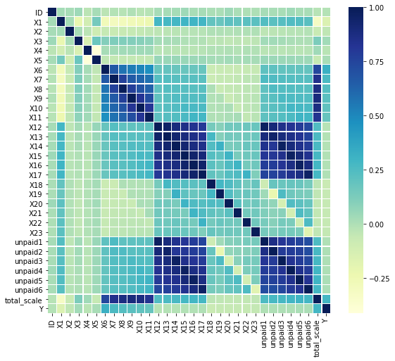

```python
data=df_normalized.copy()
data['Y']=df['Y']
f, ax = plt.subplots(figsize =(9, 8))
sns.heatmap(data.corr(), ax = ax, cmap ="YlGnBu", linewidths = 0.1)
```

#### I wanted to apply backward and forward stepwise resgression to find the best variables for model

```python
def stepwise_selection(df_normalized, y, initial_list=[],threshold_in=0.01, threshold_out = 0.5, verbose=True):
    included = list(initial_list)
    while True:
        changed=False
        # forward step
        excluded = list(set(X.columns)-set(included))
        new_pval = pd.Series(index=excluded)
        for new_column in excluded:
            model = sm.OLS(y, sm.add_constant(pd.DataFrame(X[included+[new_column]]))).fit()
            new_pval[new_column] = model.pvalues[new_column]
        best_pval = new_pval.min()
        if best_pval < threshold_in:
            best_feature = new_pval.argmin()
            included.append(best_feature)
            changed=True
            if verbose:
                print('Add  {:30} with p-value {:.6}'.format(best_feature, best_pval))

        # backward step
        model = sm.OLS(y, sm.add_constant(pd.DataFrame(X[included]))).fit()
        # use all coefs except intercept
        pvalues = model.pvalues.iloc[1:]
        worst_pval = pvalues.max() # null if pvalues is empty
        if worst_pval > threshold_out:
            changed=True
            worst_feature = pvalues.argmax()
            included.remove(worst_feature)
            if verbose:
                print('Drop {:30} with p-value {:.6}'.format(worst_feature, worst_pval))
        if not changed:
            break
    return included

result = stepwise_selection(X, y)

print('resulting features:')
print(result)
```

```
Add  X9                             with p-value 0.0
Add  X6                             with p-value 0.0
Add  X12                            with p-value 1.27002e-59
Add  X7                             with p-value 7.33224e-22
Add  X5                             with p-value 3.11474e-11
Add  unpaid1                        with p-value 2.3925e-09
Add  X18                            with p-value 1.07647e-12
Drop unpaid1                        with p-value 0.872737
```

```
Add  X1                             with p-value 3.82313e-05
Add  X3                             with p-value 1.91823e-06
Add  X4                             with p-value 1.32048e-06
Add  X8                             with p-value 0.000164207
Add  unpaid2                        with p-value 0.00132357
Add  X2                             with p-value 0.00195138
resulting features:
['X9', 'X6', 'X12', 'X7', 'X5', 'X18', 'X1', 'X3', 'X4', 'X8', 'unpaid2', 'X2']
```

```python
cols=['X9', 'X6', 'X12', 'X7', 'X5', 'X18', 'X1', 'X3', 'X4', 'X8', 'unpaid2', 'X2']
```

```python
df_last=df_normalized[cols]
X = df_last
X_train, X_test, y_train, y_test = train_test_split(X, y, test_size=0.3, random_state=0)
```

```python
lgbm = ltb.LGBMClassifier()
lgbm.fit(X_train, y_train)
lgbm_pred=lgbm.predict(X_test)
print(metrics.accuracy_score(y_test, lgbm_pred))
print(metrics.confusion_matrix(y_test, lgbm_pred))
```

```
0.8228888888888889
[[6708  352]
 [1242  698]]
```

```python
clf = DecisionTreeClassifier()
clf = clf.fit(X_train,y_train)
y_pred_test = clf.predict(X_test)
optimum_accuracy=0
for i in range(1,20):
    for k in range(1,10):
        clf=DecisionTreeClassifier(max_depth=i,min_samples_leaf=k)
        clf=clf.fit(X_train,y_train)
        clf_pred=clf.predict(X_test)
        if(metrics.accuracy_score(y_test, clf_pred))>optimum_accuracy:
            optimum_accuracy=metrics.accuracy_score(y_test, clf_pred)
            optimum_i,optimum_k=[i,k]

print('optimum_accuracy={}'.format(optimum_accuracy))
print('optimum_max_depth={}'.format(optimum_i))
print('optimum_min_samples_leaf={}'.format(optimum_k))
```

```
optimum_accuracy=0.8266666666666667
optimum_max_depth=4
optimum_min_samples_leaf=3
```

```python
clf=DecisionTreeClassifier(max_depth=optimum_i,min_samples_leaf=optimum_k)
clf=clf.fit(X_train,y_train)
clf_pred=clf.predict(X_test)
print('Accuracy score of DecisionTree= {}'.format(metrics.accuracy_score(y_test, clf_pred)))
print('Confusion Matrix is;')
print(metrics.confusion_matrix(y_test, clf_pred))
```

```
Accuracy score of DecisionTree= 0.8266666666666667
Confusion Matrix is;
[[6793  267]
 [1293  647]]
```

#### Because the data have training values ,It is not appropriate to use an unsupervised algorithm for this data but I wanted to try it.

```python
from sklearn.cluster import KMeans
kmeans = KMeans(n_clusters =2)
kmeans.fit(X)
```

```
KMeans(algorithm='auto', copy_x=True, init='k-means++', max_iter=300,
    n_clusters=2, n_init=10, n_jobs=None, precompute_distances='auto',
    random_state=None, tol=0.0001, verbose=0)
```

```python
pd.DataFrame(kmeans.labels_)[0].sum()/30000
```

```
0.39626666666666666
```

```python
print(metrics.confusion_matrix(y,pd.DataFrame(kmeans.labels_)[0]))
```

```
[[14349  9015]
 [ 3763  2873]]
```

```python
print('Accuracy score of KNN algorithm = {}'.format(metrics.accuracy_score(y,pd.DataFrame(kmeans.labels_)[0])))
print('Confusion Matrix is;')
print(metrics.confusion_matrix(y,pd.DataFrame(kmeans.labels_)[0]))
```

```
Accuracy score of KNN algorithm = 0.5740666666666666
Confusion Matrix is;
[[14349  9015]
 [ 3763  2873]]
```

```python
cols=list(set(list(df.columns))-set(df['Y']))
```

```python
df[cols] = df[cols]/df[cols].max()
df.describe().transpose()
```

|  | count | mean | std | min | 25% | 50% | 75% | max |
| --- | --- | --- | --- | --- | --- | --- | --- | --- |
| ID | 30000.0 | 0.500017 | 0.288680 | 0.000033 | 0.250025 | 0.500017 | 0.750008 | 1.0 |
| X1 | 30000.0 | 0.167484 | 0.129748 | 0.010000 | 0.050000 | 0.140000 | 0.240000 | 1.0 |
| X2 | 30000.0 | 0.801867 | 0.244565 | 0.500000 | 0.500000 | 1.000000 | 1.000000 | 1.0 |
| X3 | 30000.0 | 0.308856 | 0.131725 | 0.000000 | 0.166667 | 0.333333 | 0.333333 | 1.0 |
| X4 | 30000.0 | 0.517289 | 0.173990 | 0.000000 | 0.333333 | 0.666667 | 0.666667 | 1.0 |
| X5 | 30000.0 | 0.449184 | 0.116682 | 0.265823 | 0.354430 | 0.430380 | 0.518987 | 1.0 |
| X6 | 30000.0 | -0.002087 | 0.140475 | -0.250000 | -0.125000 | 0.000000 | 0.000000 | 1.0 |
| X7 | 30000.0 | -0.016721 | 0.149648 | -0.250000 | -0.125000 | 0.000000 | 0.000000 | 1.0 |
| X8 | 30000.0 | -0.020775 | 0.149608 | -0.250000 | -0.125000 | 0.000000 | 0.000000 | 1.0 |
| X9 | 30000.0 | -0.027583 | 0.146142 | -0.250000 | -0.125000 | 0.000000 | 0.000000 | 1.0 |
| X10 | 30000.0 | -0.033275 | 0.141648 | -0.250000 | -0.125000 | 0.000000 | 0.000000 | 1.0 |
| X11 | 30000.0 | -0.036388 | 0.143748 | -0.250000 | -0.125000 | 0.000000 | 0.000000 | 1.0 |
| X12 | 30000.0 | 0.053108 | 0.076345 | -0.171672 | 0.003690 | 0.023205 | 0.069560 | 1.0 |
| X13 | 30000.0 | 0.049982 | 0.072336 | -0.070917 | 0.003033 | 0.021546 | 0.065052 | 1.0 |
| X14 | 30000.0 | 0.028252 | 0.041674 | -0.094505 | 0.001602 | 0.012072 | 0.036155 | 1.0 |
| X15 | 30000.0 | 0.048524 | 0.072156 | -0.190671 | 0.002610 | 0.021369 | 0.061134 | 1.0 |
| X16 | 30000.0 | 0.043478 | 0.065573 | -0.087723 | 0.001901 | 0.019527 | 0.054133 | 1.0 |
| X17 | 30000.0 | 0.040421 | 0.061928 | -0.353141 | 0.001306 | 0.017752 | 0.051160 | 1.0 |
| X18 | 30000.0 | 0.006483 | 0.018961 | 0.000000 | 0.001145 | 0.002404 | 0.005731 | 1.0 |
| X19 | 30000.0 | 0.003516 | 0.013680 | 0.000000 | 0.000495 | 0.001193 | 0.002969 | 1.0 |
| X20 | 30000.0 | 0.005832 | 0.019650 | 0.000000 | 0.000435 | 0.002009 | 0.005028 | 1.0 |
| X21 | 30000.0 | 0.007771 | 0.025227 | 0.000000 | 0.000477 | 0.002415 | 0.006463 | 1.0 |
| X22 | 30000.0 | 0.011252 | 0.035820 | 0.000000 | 0.000592 | 0.003517 | 0.009452 | 1.0 |
| X23 | 30000.0 | 0.009865 | 0.033627 | 0.000000 | 0.000223 | 0.002837 | 0.007566 | 1.0 |
| Y | 30000.0 | 0.221200 | 0.415062 | 0.000000 | 0.000000 | 0.000000 | 0.000000 | 1.0 |
| total_scale | 30000.0 | -0.030406 | 0.163696 | -0.333333 | -0.138889 | 0.000000 | 0.000000 | 1.0 |
| unpaid1 | 30000.0 | 0.049861 | 0.080083 | -0.803023 | 0.000815 | 0.020302 | 0.068118 | 1.0 |
| unpaid2 | 30000.0 | 0.046354 | 0.077760 | -1.824188 | 0.000353 | 0.019398 | 0.063306 | 1.0 |
| unpaid3 | 30000.0 | 0.027095 | 0.044931 | -0.554149 | 0.000170 | 0.011521 | 0.036501 | 1.0 |
| unpaid4 | 30000.0 | 0.045672 | 0.076285 | -0.792551 | 0.000273 | 0.020164 | 0.059720 | 1.0 |
| unpaid5 | 30000.0 | 0.040485 | 0.069033 | -0.472405 | 0.000000 | 0.017714 | 0.053537 | 1.0 |
| unpaid6 | 30000.0 | 0.036928 | 0.065998 | -0.751470 | 0.000000 | 0.015280 | 0.050545 | 1.0 |

```python
X = df[cols].values
y = df['Y'].values

X_train, X_test, y_train, y_test = train_test_split(X, y, test_size=0.30, random_state=0)
print(X_train.shape); print(X_test.shape)
```

```
(21000, 32)
(9000, 32)
```

```python
from sklearn.neural_network import MLPClassifier

mlp = MLPClassifier(hidden_layer_sizes=(10,10,10), activation='relu', solver='adam', max_iter=500)
mlp.fit(X_train,y_train)

predict_test = mlp.predict(X_test)
```

```python
from sklearn.metrics import classification_report,confusion_matrix
print(confusion_matrix(y_test,predict_test))
print(classification_report(y_test,predict_test))
print('Accuracy score of neural network classification algorithm = {}'.format(metrics.accuracy_score(y_test,predict_test)))
```

```
[[7060    0]
 [   0 1940]]
              precision    recall  f1-score   support

         0.0       1.00      1.00      1.00      7060
         1.0       1.00      1.00      1.00      1940

   micro avg       1.00      1.00      1.00      9000
   macro avg       1.00      1.00      1.00      9000
weighted avg       1.00      1.00      1.00      9000

Accuracy score of neural network classification algorithm = 1.0
```

```python
X_train, X_test, y_train, y_test = train_test_split(X, y, test_size=0.99, random_state=0)
print(X_train.shape); print(X_test.shape)
```

```
(300, 32)
(29700, 32)
```

```python
mlp = MLPClassifier(hidden_layer_sizes=(10,10,10), activation='relu', solver='adam', max_iter=500)
mlp.fit(X_train,y_train)

predict_test = mlp.predict(X_test)
print(confusion_matrix(y_test,predict_test))
print(classification_report(y_test,predict_test))
print('Accuracy score of neural network classification algorithm = {}'.format(metrics.accuracy_score(y_test,predict_test)))
```

```
[[23121     0]
 [   22  6557]]
              precision    recall  f1-score   support

         0.0       1.00      1.00      1.00     23121
         1.0       1.00      1.00      1.00      6579

   micro avg       1.00      1.00      1.00     29700
   macro avg       1.00      1.00      1.00     29700
weighted avg       1.00      1.00      1.00     29700

Accuracy score of neural network classification algorithm = 0.9992592592592593
```